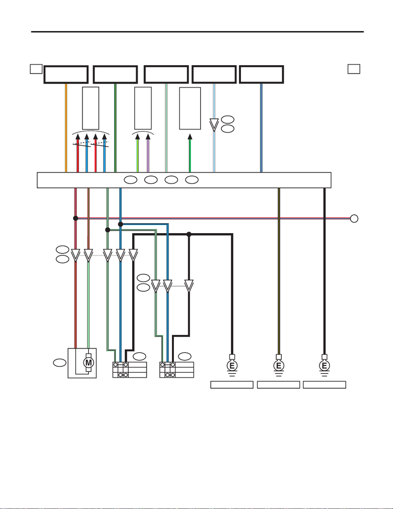

WI-295

Keyless Entry System

WIRING SYSTEM

30.Keyless Entry System

A: WIRING DIAGRAM

WI-44493

a a

D83

D84

3

17

18

15

16

15

16

3

3

D72

D7A:

i76

i101

D125

i229

B551

W/LW/L

L/R

L/R

G/R

W/L

GD18

B3

W/GD1

C6

A:

B280

B:

B281

C:

i84

D:

i171

Y/RA32

B7

R/G

LG

LG/B

L/B

R/L

R/L

D2

R/G D4

LG/B C9

L/B C20

B

R/G R/L

LG

LG/B LG/B

L/B L/B

BB

A

LOCK

OFF

UNLOCK

BC1

B/Y A1

LOCK

OFF

UNLOCK

LB28

RB20

LC35

RC27

G/YC4

1

4

A3

A9

A1

B/Y

B

B

R/G

P/LD8

LG/B LG/B

L/B L/B

B

LG/B

L/B

B

4

2

5B

REF. TO GND [c] REF. TO GND [j] REF. TO GND [e]

REF. TO CAN

COMMUNICATION

SYSTEM [b]

PASSENGER'S

DOOR LOCK

SWITCH

POWER WINDOW

MAIN SWITCH

(DOOR LOCK SWITCH)

FRONT DOOR

LOCK ACTUATOR LH

REF. TO INTERIOR

LIGHT SYSTEM [b]

REF. TO

TURN SIGNAL LIGHT

& HAZARD LIGHT

SYSTEM [b]

BODY INTEGRATED UNIT

FB-6

F/B FUSE NO. 3

(B)

FB-38

F/B FUSE NO. 12

(IG)

FB-18

F/B FUSE NO. 7

(B)

MB-29

M/B FUSE NO. 8

(B)

FB-29

F/B FUSE NO. 31

(ACC)

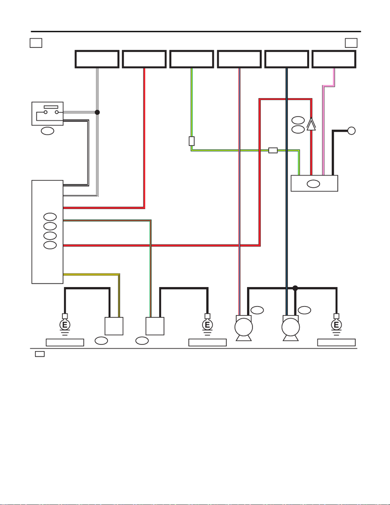

WI-296

Keyless Entry System

WIRING SYSTEM

WI-44494

b b

1

B555

B164

B

i102

R167

1

2

1

2

3

4

5

TP

TP

TP

B/L

R/L

RA24

W/BB6

R

W/B

W/B1

B/W2

B/WA4

G/Y4

Y/BA20

G/RC10

C: i84

D: i171

B: B281

A: B280

1 Y/B

2B

i13

2 G/R

3B

RD11

B

B

P

3

4

5

R

P

R

G/Y

FB-31

F/B FUSE NO. 4

(IG)

FB-11

F/B FUSE NO. 15

(B)

MB-28

M/B FUSE NO. 14

(B)

MB-21

HORN RELAY

MB-20

M/B FUSE NO. 9

KEY WARNING SWITCH

BODY INTEGRATED

UNIT

: WITH TPMS

KEYLESS

BUZZER

: WITHOUT TPMS : 7

WITH TPMS : 5

: WITHOUT TPMS : 4

WITH TPMS : 6

: WITHOUT TPMS : 3

WITH TPMS : 11

: WITHOUT TPMS : KEYLESS ENTRY CM

WITH TPMS : TPMS & KEYLESS ENTRY CM

: WITHOUT TPMS : R80

WITH TPMS : R221

F47F5

B1

B1

B

REF. TO GND [a]

B

REF. TO GND [b]

TRUNK LID OPENER

SWITCH

B

REF. TO GND [e]

B/L2

R/L2

HORNHORN

MB-19

M/B FUSE NO. 9

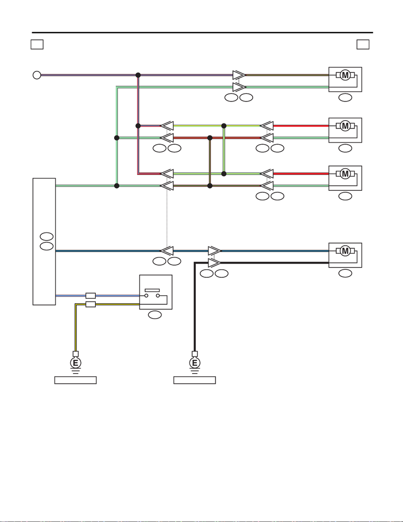

WI-297

Keyless Entry System

WIRING SYSTEM

6

WI-44495

c c

17

2

12

13

10

11

14

18

A

R186

D32

D18

i76 D83

R24 R60

R13 D28

D26

R10 D22

i102 R167

i53 R98

B: B281

D: i171

B116

CVT

CVT

B/L

B2

1D7

R/L

R

LG 1

4

R/G

LG 1

4

LG

LG

R/L

R/G

B/L

R/GR/G

LG

LG/Y LG/Y

R/G

LG/Y

R

LG

R/L

R

LG 1

4

R/G

LG

R

LG

R/L

R/G

LG/Y LG/Y

B/L B/L

B18 P/L

D3 LG

B/L

1

2B/Y

P/L

B/Y

B

8

7

8

7

P RANGE

SWITCH

SELECT LEVER

REAR DOOR LOCK

ACTUATOR LH

BODY INTEGRATED

UNIT

FRONT DOOR LOCK

ACTUATOR RH

REAR DOOR LOCK

ACTUATOR RH

TRUNK LID LOCK

ACTUATOR

REF. TO GND [d] REF. TO GND [h]

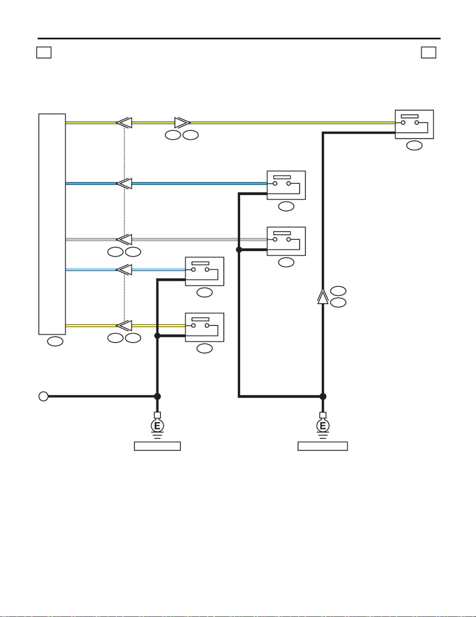

WI-298

Keyless Entry System

WIRING SYSTEM

WI-44496

d d

15

16

15

16

17

1

6

i84C:

R22

R9

B

i2 R339

R16

R12

i195 R382

R186

R24 R60

R24

R60

1

3

1

3

B

B

BB

Y/W Y/W

L/W L/W

C24

C14

B

B

1

3

1

3

W/R W/R

L/O L/O

C25

C13

C33

B

B

W/R

L/O

Y/L

B

3

2

Y/LY/L Y/L

B

TRUNK LID LOCK

SWITCH

FRONT DOOR

SWITCH RH

REAR DOOR

SWITCH RH

FRONT DOOR

SWITCH LH

BODY INTEGRATED

UNIT

REAR DOOR

SWITCH LH

REF. TO GND [h] REF. TO GND [f]

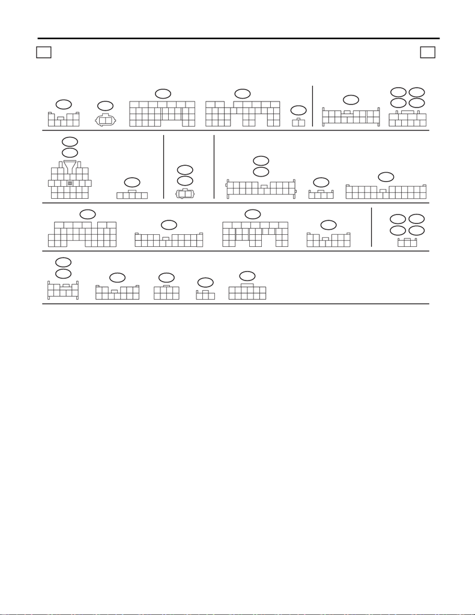

WI-299

Keyless Entry System

WIRING SYSTEM

i229

12 345

6789

10 11 12

WI-44497

e e

B555

12

i171D:

19

18

20 21

22

23

26

24

25

27

28 29

30 31

98

15

17

16

1234567

i195

123

R22R12

R9

R16

R60

12 345

6789

10 11 12

i2

12345 6789

10 11 12 13 14 15 16 17 18 19 20

R186

123

B116

123

45678

(GR)

B164

12

B280

18

2719 20 21 22

23

26

24

25

28 29 3332 3430 31

98

15

1413121110

17

16

1234567

A:

B281B:

5672134

29

10 11 12 13 14 15

2524

16

30

98

17 18 19

20

28

21 22 23

3231

26 27

33 34 35

D7

123

89

10

4

11 12 13 14 15 16

56

7

A:

1

76589

10

342

D72

D32

D26

D18

D84

D83

19

18

20 21 22

1514131211

1

3

24

5

7

6

98

10

17

25

24

26 27 2823

16

D125

12345

(B)

F47

(B)

F5

12

3412 89

10 11

12 13 14 15 16 17 18 19 20 21 22 23 24

567

i53

89

19 20

1234 567

10 11 12 13 14 15 16 17 18

i102

i84C:

19

18

21

20

2322 24 25 26

17

1

23

4

56

27

28 29 30

31 32 33 34 35

798

151413121110 16

R13

R10

65

21

4

3

87

R80

1234

5678

R221

11 12

9

10

78

65341

2

i13

(GR)

2143

LIST OF CONNECTORS